# Analyzing rsEEG and FB Power across Topography Part 2

Leandro Ledesma

2024-10-11

### Universal block code settings

```r
knitr::opts_chunk$set(echo = FALSE)
knitr::opts_chunk$set(message = FALSE)
knitr::opts_chunk$set(comment = NULL)
knitr::opts_chunk$set(warning = FALSE)
```

### Index subjects by those that met the requirements

- No self-report injury
- No Epilepsy
- Removing missing data
- No one below ‘IQ’ of 70 (more than 2 SD below the mean)
- Extremely poor spellers (more than 3 SD below the mean)
- Issues with EEG recordings
- Did not survive EEG cleaning

### Check for missing data

```
             ID             Sex             Age           Group            CFIT
              0               0               0               0               0
  SpellingError       Condition   frontal_delta   frontal_theta   frontal_alpha
              0               0               0               0               0
   frontal_beta  temporal_delta  temporal_theta  temporal_alpha   temporal_beta
              0               0               0               0               0
 parietal_delta  parietal_theta  parietal_alpha   parietal_beta occipital_delta
              0               0               0               0               0
occipital_theta occipital_alpha  occipital_beta
              0               0               0
```

### Descriptives

|  | vars | n | mean | sd | median | trimmed | mad | min | max | range | skew | kurtosis | se |
| --- | --- | --- | --- | --- | --- | --- | --- | --- | --- | --- | --- | --- | --- |
| Age | 1 | 449 | 20.27 | 4.44 | 19 | 19.55 | 2.97 | 15 | 36 | 21 | 1.38 | 1.35 | 0.21 |
| CFIT | 1 | 449 | 30.87 | 5.37 | 32 | 31.20 | 4.45 | 18 | 42 | 24 | -0.54 | -0.32 | 0.25 |
| SpellingEr | 1 | 449 | 13.38 | 8.62 | 12 | 12.60 | 8.90 | 0 | 41 | 41 | 0.73 | -0.01 | 0.41 |

|  | BF | IC |
| --- | --- | --- |
| Female | 153 | 103 |
| Male | 93 | 100 |

### Graph the distributions of numeric variables (before log)

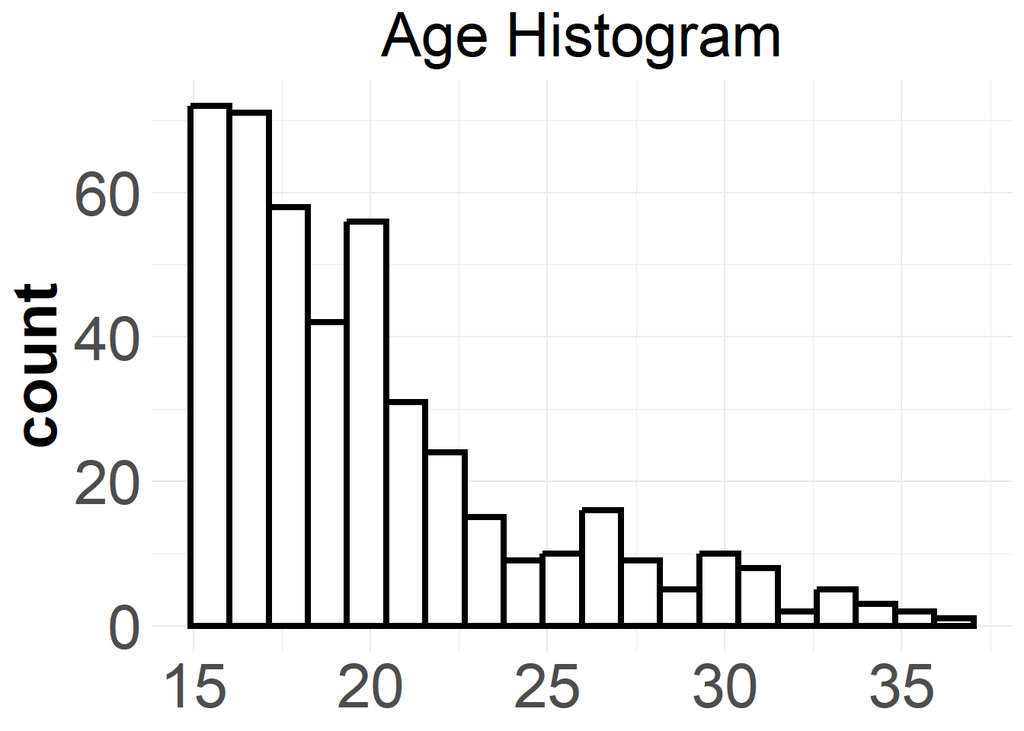

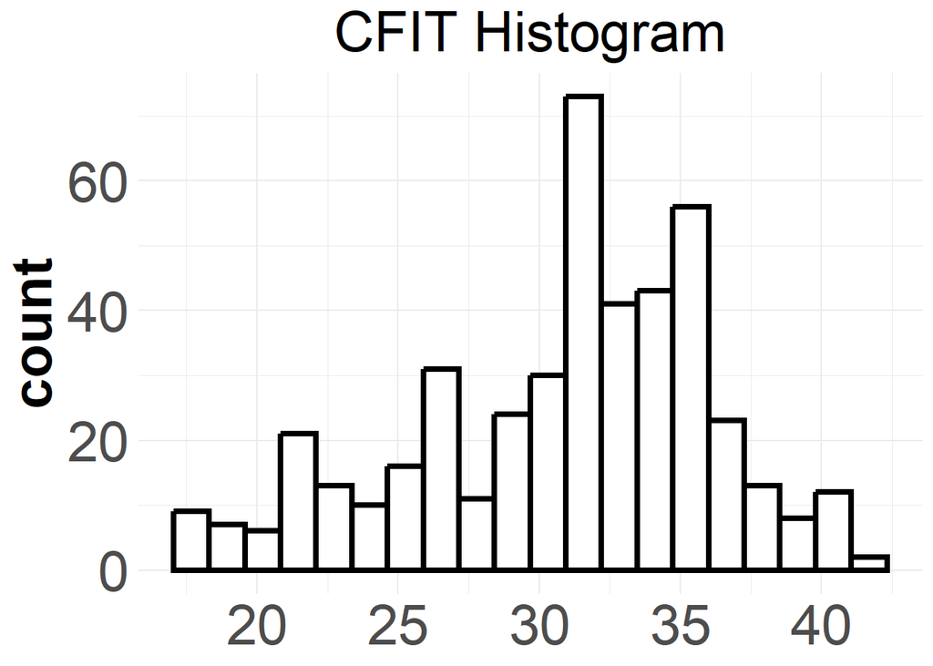

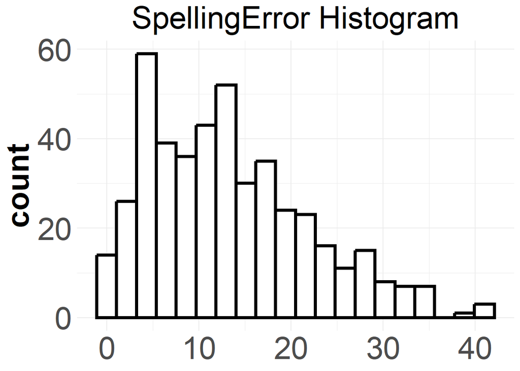

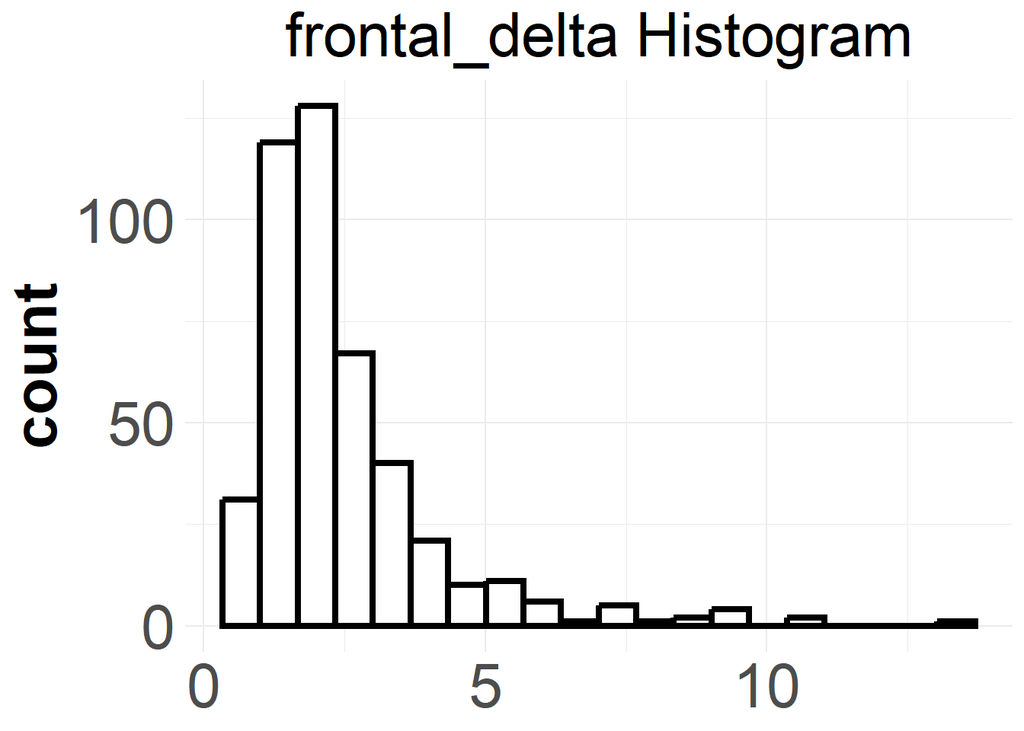

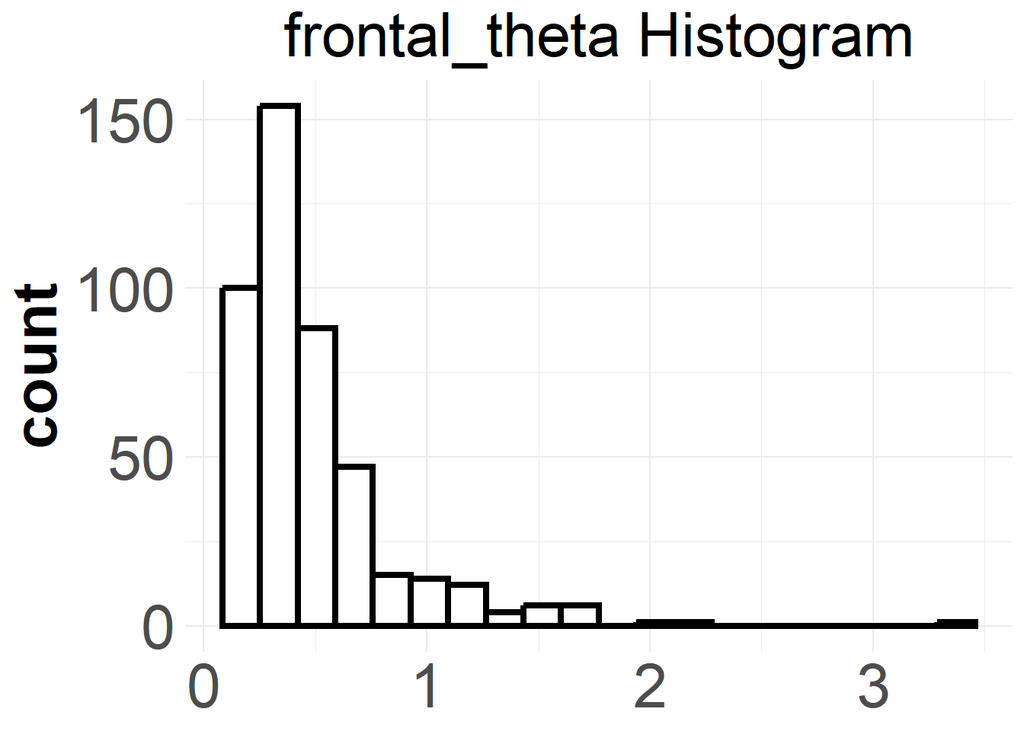

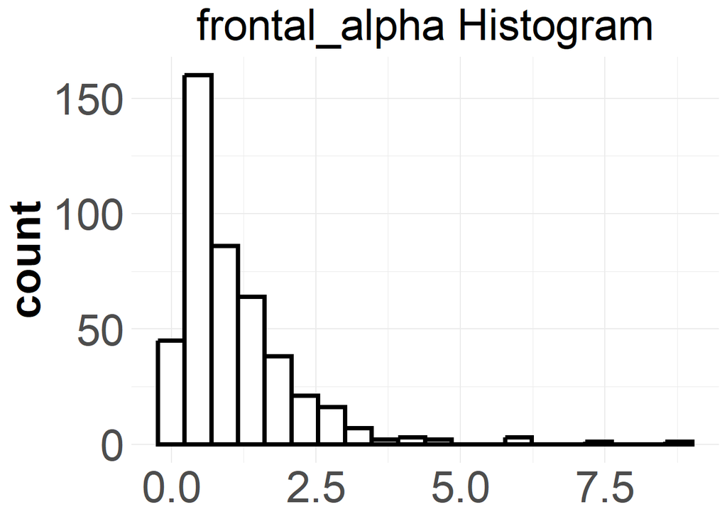

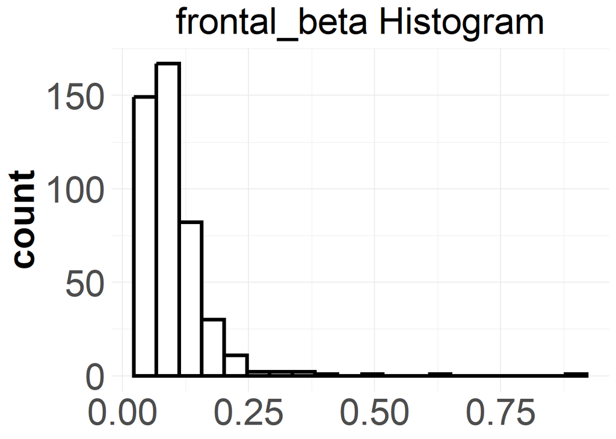

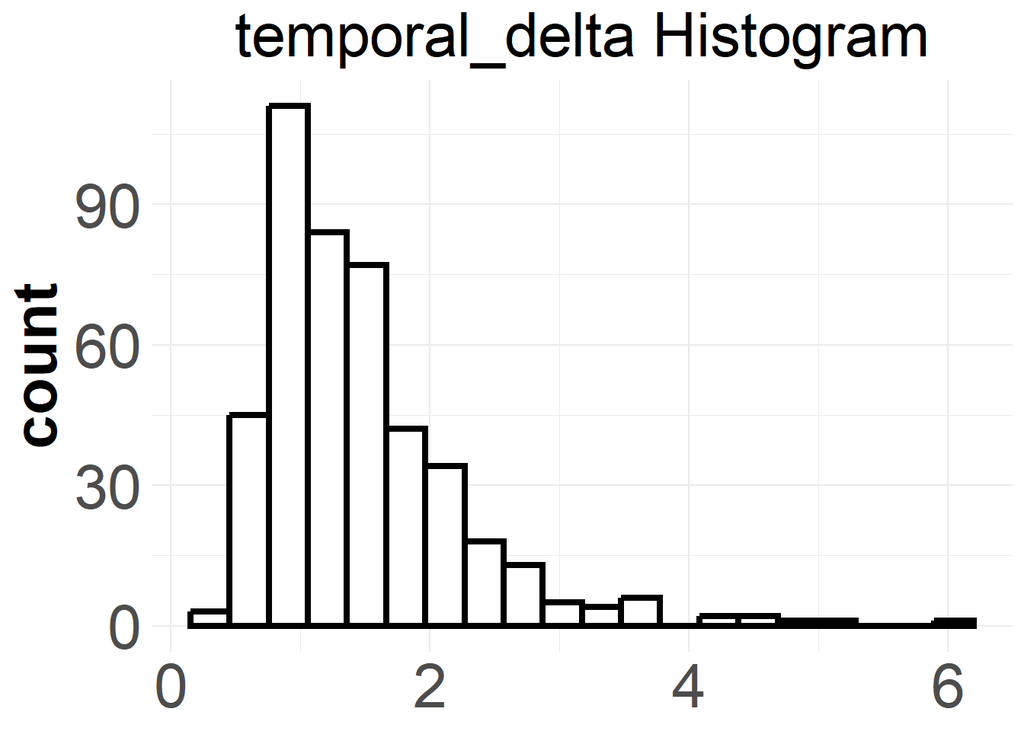

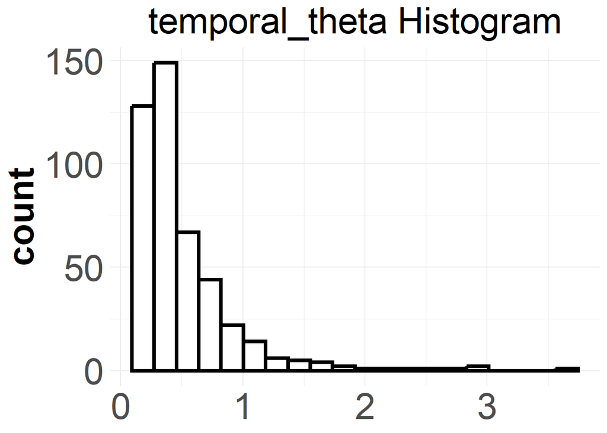

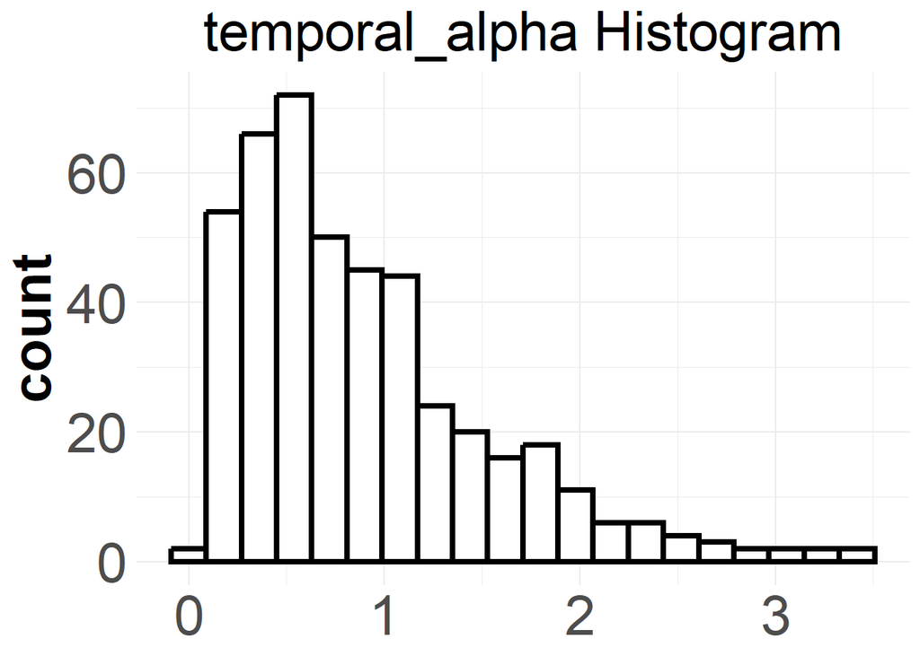

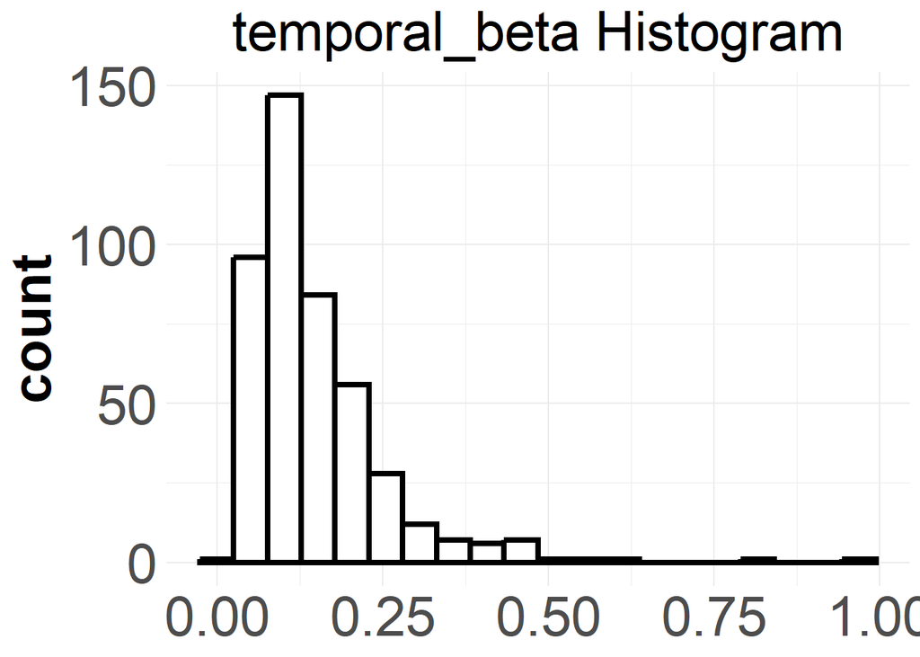

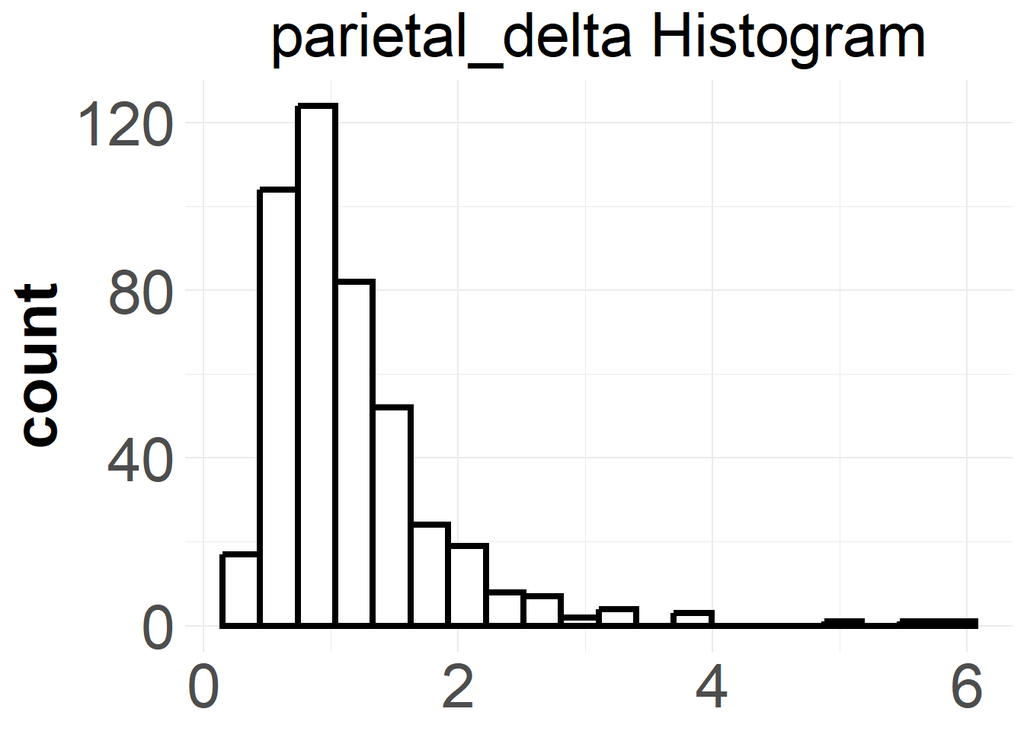

[7 more figures not shown]

### Graph the distributions of numeric variables (after log)

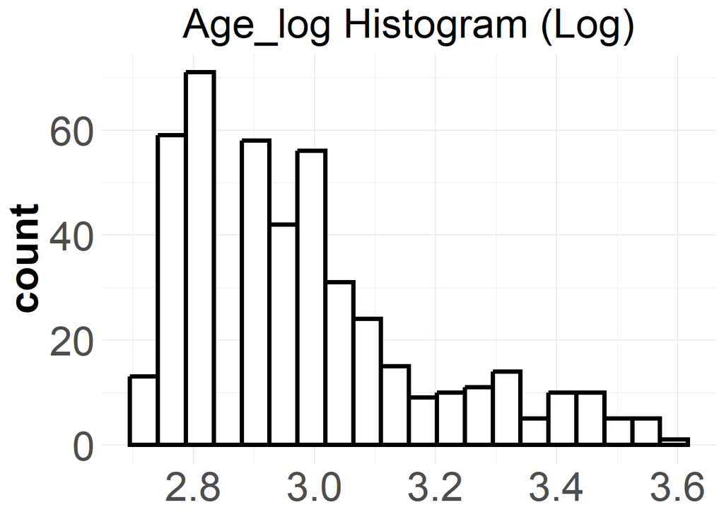

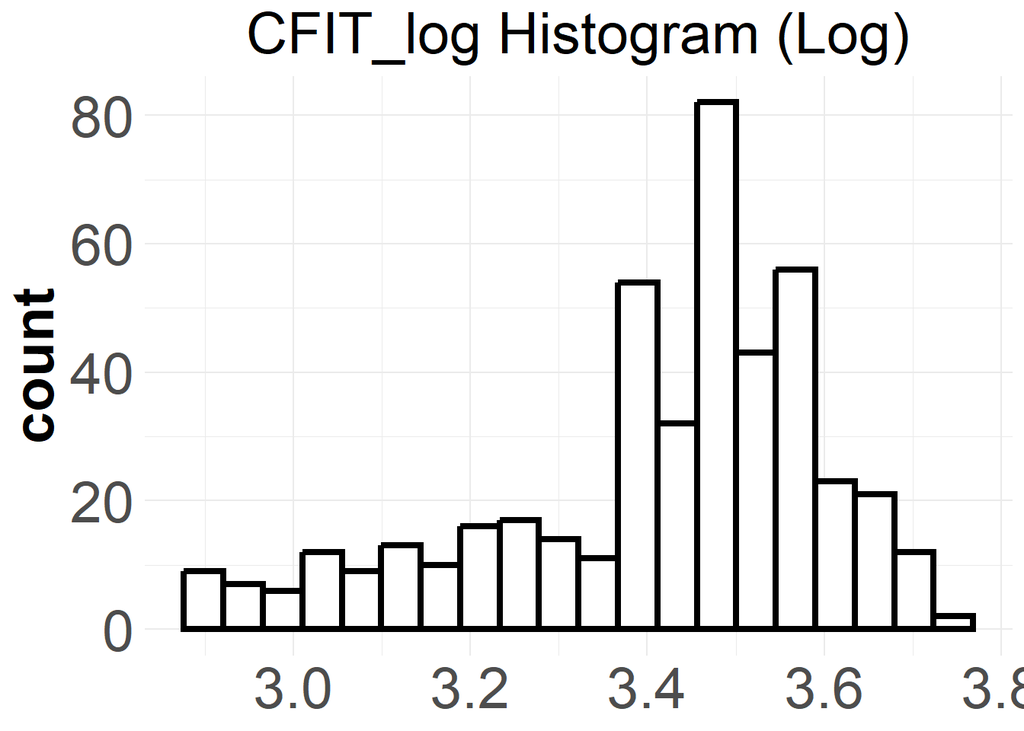

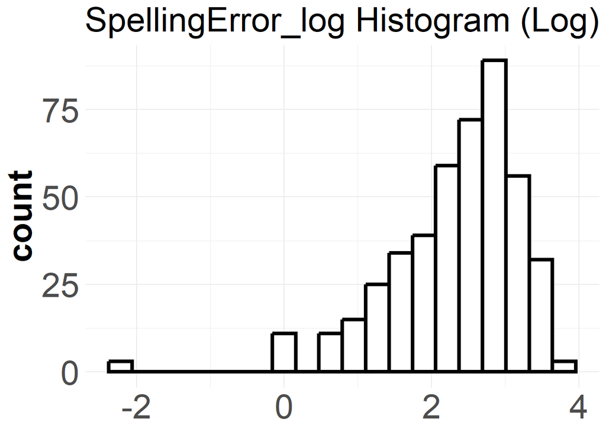

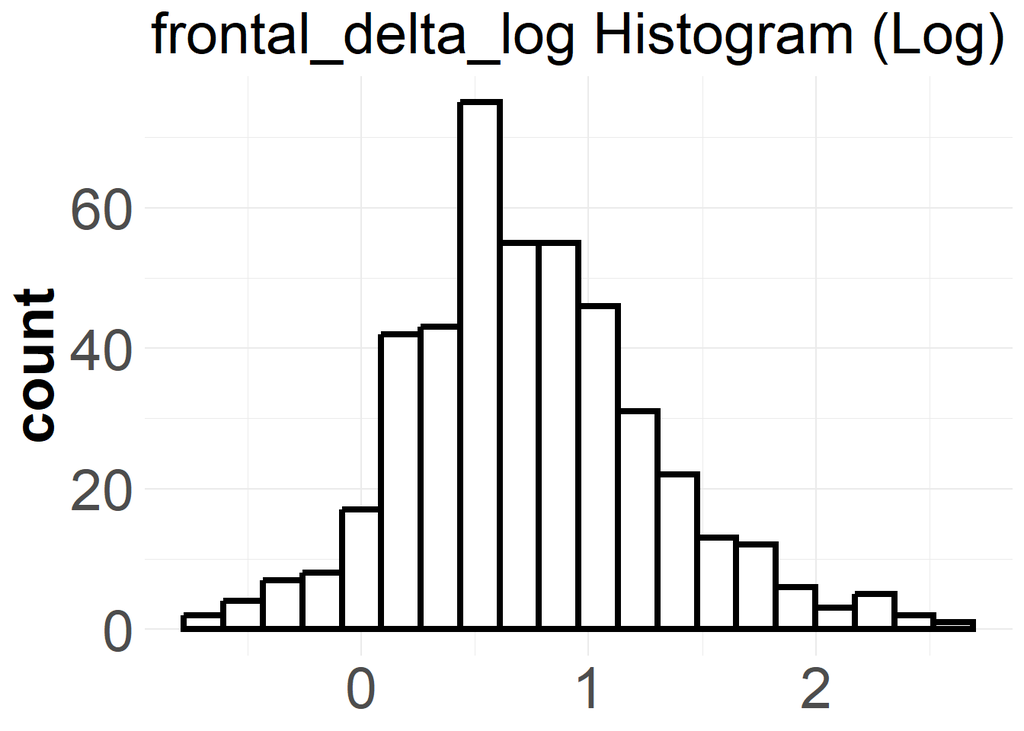

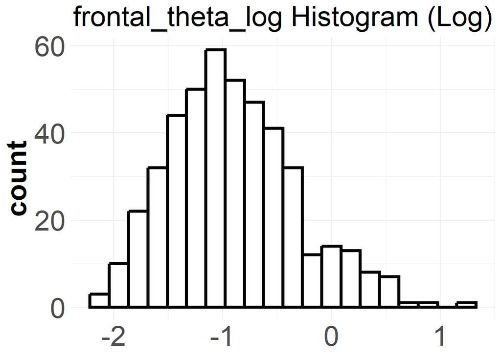

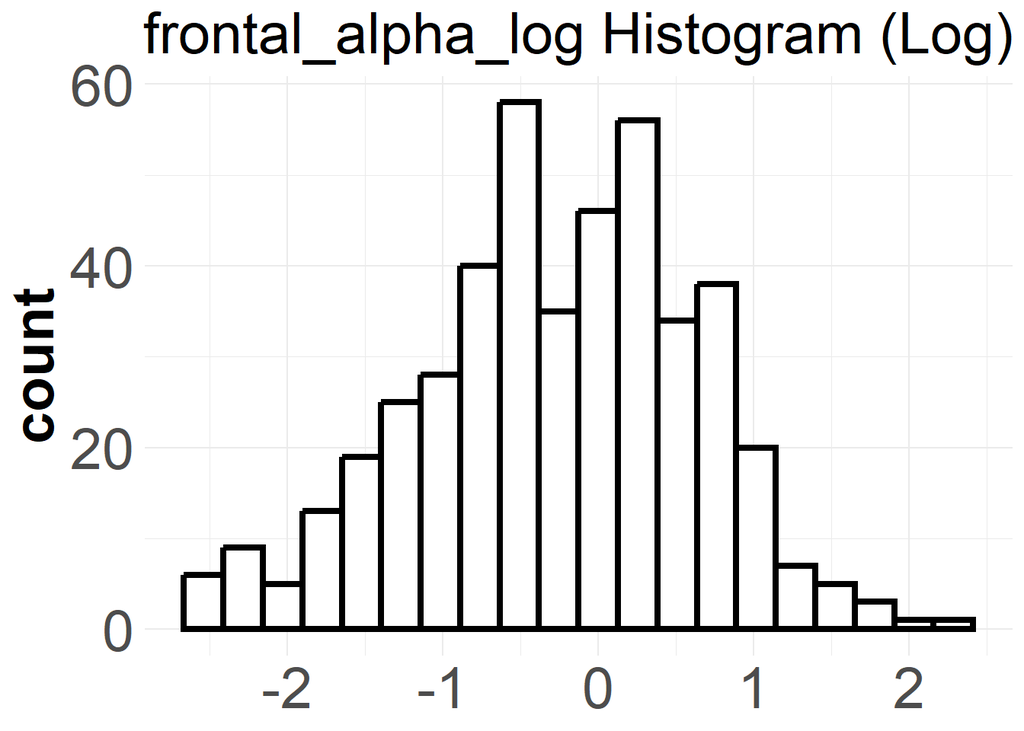

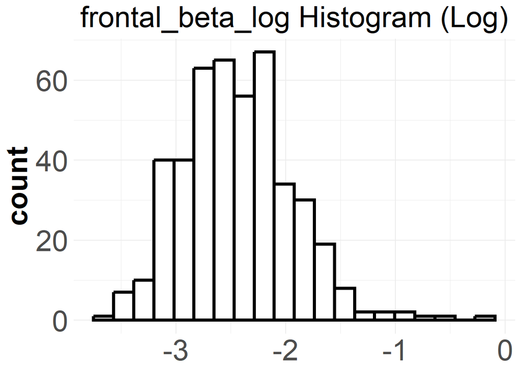

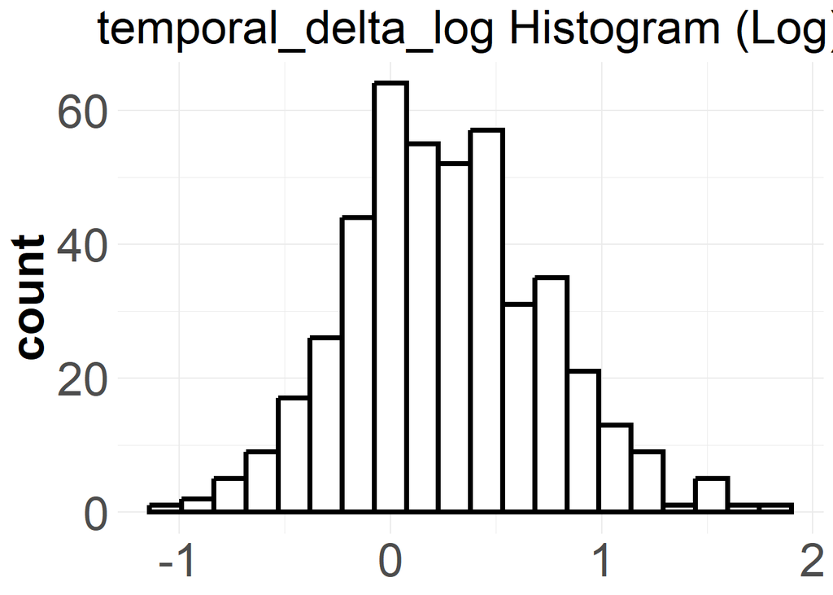

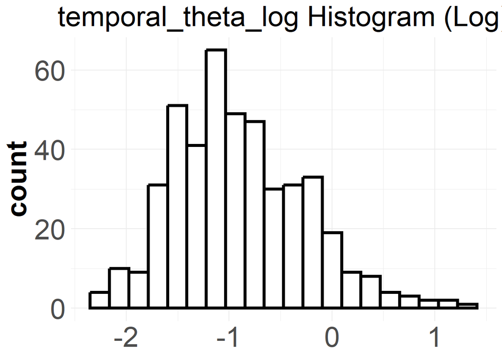

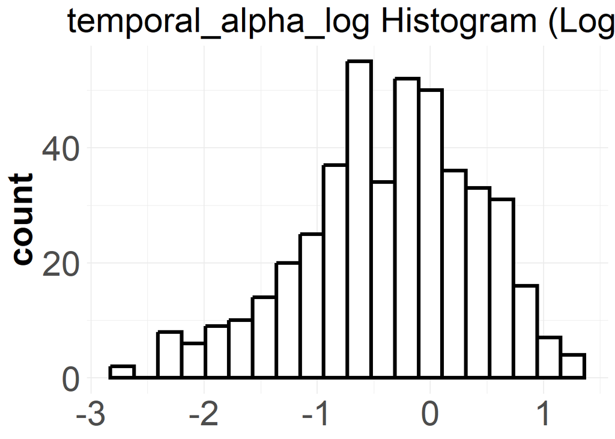

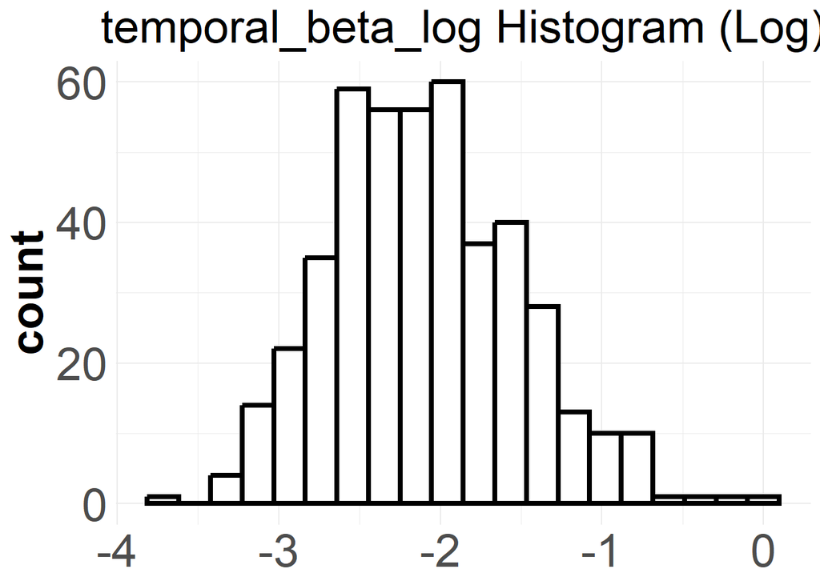

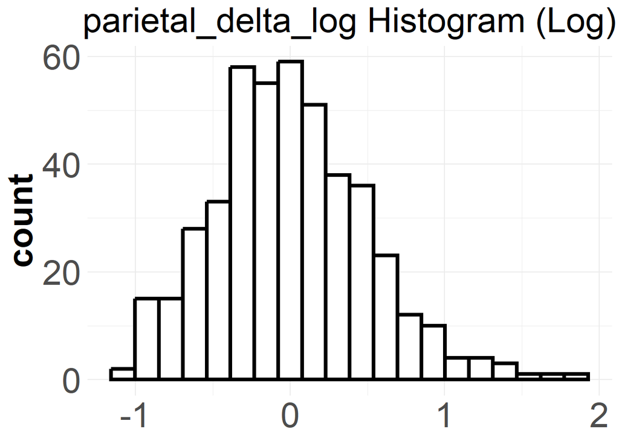

[7 more figures not shown]

### Multicollinearity? (Correlation Matrix)

|  | Age_log | CFIT_log | SpellingError_log |
| --- | --- | --- | --- |
| Age_log | 1.00 | 0.12 | -0.24 |
| CFIT_log | 0.12 | 1.00 | -0.52 |
| SpellingError_log | -0.24 | -0.52 | 1.00 |

### Converting data to Long format

Data in R and most statistical software must (or mostly) be in long format to be compatible with statistical functions.

### Analysis Plan (Simple- no interactions)

Simplifying the analysis by investigating the relationship between spelling and power at 4 frequency bands (delta, theta, alpha, beta) while controlling for age, and topography. Since there are 4 outcome variables then we will be interpreting 4 models.

We will be using dummy coding for right now, thus the intercepts of the model will represent the power of the frontal region for a female raised by her biological family.

- Type I sums of squares were used for calculating the p values

```
          occipital parietal temporal
frontal           0        0        0
occipital         1        0        0
parietal          0        1        0
temporal          0        0        1
```

```
  M
F 0
M 1
```

```
   IC
BF  0
IC  1
```

```
Call:
lm(formula = Power ~ Age_log + Sex + CFIT_log + Group + Topography +
    SpellingError_log, data = Delta.long)

Residuals:
     Min       1Q   Median       3Q      Max
-1.35402 -0.31766 -0.04985  0.26795  2.13115

Coefficients:
                    Estimate Std. Error t value Pr(>|t|)
(Intercept)          4.63631    0.33422  13.872  < 2e-16 ***
Age_log             -0.93409    0.05905 -15.820  < 2e-16 ***
SexM                -0.04063    0.02314  -1.755   0.0794 .
CFIT_log            -0.32203    0.07267  -4.431 9.93e-06 ***
GroupIC             -0.03405    0.02844  -1.197   0.2313
Topographyoccipital -0.14908    0.03146  -4.739 2.32e-06 ***
Topographyparietal  -0.74198    0.03146 -23.586  < 2e-16 ***
Topographytemporal  -0.48363    0.03146 -15.374  < 2e-16 ***
SpellingError_log    0.01410    0.01675   0.842   0.4002
---
Signif. codes:  0 '***' 0.001 '**' 0.01 '*' 0.05 '.' 0.1 ' ' 1

Residual standard error: 0.4714 on 1787 degrees of freedom
Multiple R-squared:  0.3589,    Adjusted R-squared:  0.3561
F-statistic: 125.1 on 8 and 1787 DF,  p-value: < 2.2e-16
```

```
Call:
lm(formula = Power ~ Age_log + Sex + CFIT_log + Group + Topography +
    SpellingError_log, data = Theta.long)

Residuals:
     Min       1Q   Median       3Q      Max
-1.61365 -0.50744 -0.08671  0.41898  2.54924

Coefficients:
                     Estimate Std. Error t value Pr(>|t|)
(Intercept)          1.021344   0.476143   2.145 0.032084 *
Age_log             -0.840725   0.084119  -9.994  < 2e-16 ***
SexM                -0.048126   0.032970  -1.460 0.144554
CFIT_log             0.155499   0.103532   1.502 0.133288
GroupIC              0.135879   0.040513   3.354 0.000813 ***
Topographyoccipital  0.436035   0.044817   9.729  < 2e-16 ***
Topographyparietal  -0.164811   0.044817  -3.677 0.000243 ***
Topographytemporal   0.004261   0.044817   0.095 0.924260
SpellingError_log    0.006723   0.023870   0.282 0.778250
---
Signif. codes:  0 '***' 0.001 '**' 0.01 '*' 0.05 '.' 0.1 ' ' 1

Residual standard error: 0.6715 on 1787 degrees of freedom
Multiple R-squared:  0.1621,    Adjusted R-squared:  0.1584
F-statistic: 43.22 on 8 and 1787 DF,  p-value: < 2.2e-16
```

```
Call:
lm(formula = Power ~ Age_log + Sex + CFIT_log + Group + Topography +
    SpellingError_log, data = Alpha.long)

Residuals:
    Min      1Q  Median      3Q     Max
-3.5903 -0.5480  0.0851  0.6736  2.4539

Coefficients:
                    Estimate Std. Error t value Pr(>|t|)
(Intercept)          0.17727    0.66523   0.266   0.7899
Age_log             -0.50768    0.11752  -4.320 1.65e-05 ***
SexM                 0.01145    0.04606   0.249   0.8037
CFIT_log             0.32918    0.14465   2.276   0.0230 *
GroupIC              0.10760    0.05660   1.901   0.0575 .
Topographyoccipital  1.25712    0.06261  20.077  < 2e-16 ***
Topographyparietal   0.37213    0.06261   5.943 3.35e-09 ***
Topographytemporal  -0.09869    0.06261  -1.576   0.1152
SpellingError_log   -0.04723    0.03335  -1.416   0.1569
---
Signif. codes:  0 '***' 0.001 '**' 0.01 '*' 0.05 '.' 0.1 ' ' 1

Residual standard error: 0.9382 on 1787 degrees of freedom
Multiple R-squared:  0.2555,    Adjusted R-squared:  0.2522
F-statistic: 76.66 on 8 and 1787 DF,  p-value: < 2.2e-16
```

```
Call:
lm(formula = Power ~ Age_log + Sex + CFIT_log + Group + Topography +
    SpellingError_log, data = Beta.long)

Residuals:
     Min       1Q   Median       3Q      Max
-1.55581 -0.39333 -0.01631  0.34595  2.20449

Coefficients:
                     Estimate Std. Error t value Pr(>|t|)
(Intercept)         -1.503474   0.394203  -3.814 0.000141 ***
Age_log             -0.278646   0.069643  -4.001 6.56e-05 ***
SexM                -0.166006   0.027296  -6.082 1.45e-09 ***
CFIT_log            -0.008690   0.085715  -0.101 0.919258
GroupIC              0.020753   0.033541   0.619 0.536175
Topographyoccipital  0.718941   0.037104  19.376  < 2e-16 ***
Topographyparietal  -0.071625   0.037104  -1.930 0.053719 .
Topographytemporal   0.347658   0.037104   9.370  < 2e-16 ***
SpellingError_log   -0.005467   0.019762  -0.277 0.782092
---
Signif. codes:  0 '***' 0.001 '**' 0.01 '*' 0.05 '.' 0.1 ' ' 1

Residual standard error: 0.5559 on 1787 degrees of freedom
Multiple R-squared:  0.2618,    Adjusted R-squared:  0.2585
F-statistic: 79.23 on 8 and 1787 DF,  p-value: < 2.2e-16
```

### Analysis Plan (2 way-interactions)

Is spelling error predictive of absolute power in some ages but not others? Thus, here we regress absolute power for four frequency bands (delta, theta, alpha, beta) on the same covariates as above with an age x spelling error interaction.

- Type III sums of squares were used for calculating the p values
- Gives us more power when examining interactions
- Order of the covariates should not matter

```
Anova Table (Type III tests)

Response: Power
                          Sum Sq   Df  F value    Pr(>F)
(Intercept)                10.07    1  45.2984 2.272e-11 ***
Sex                         0.73    1   3.2916    0.0698 .
CFIT_log                    4.11    1  18.4755 1.814e-05 ***
Group                       0.35    1   1.5694    0.2105
Topography                150.06    3 225.0593 < 2.2e-16 ***
Age_log                     5.04    1  22.6569 2.093e-06 ***
SpellingError_log           0.09    1   0.4204    0.5168
Age_log:SpellingError_log   0.08    1   0.3434    0.5580
Residuals                 396.95 1786
---
Signif. codes:  0 '***' 0.001 '**' 0.01 '*' 0.05 '.' 0.1 ' ' 1
```

```
Anova Table (Type III tests)

Response: Power
                          Sum Sq   Df F value    Pr(>F)
(Intercept)                 0.02    1  0.0489  0.825050
Sex                         1.12    1  2.4929  0.114535
CFIT_log                    1.21    1  2.6858  0.101424
Group                       4.68    1 10.3876  0.001292 **
Topography                 89.05    3 65.8341 < 2.2e-16 ***
Age_log                     2.52    1  5.5994  0.018072 *
SpellingError_log           0.52    1  1.1444  0.284867
Age_log:SpellingError_log   0.50    1  1.1054  0.293228
Residuals                 805.29 1786
---
Signif. codes:  0 '***' 0.001 '**' 0.01 '*' 0.05 '.' 0.1 ' ' 1
```

```
Anova Table (Type III tests)

Response: Power
                           Sum Sq   Df  F value    Pr(>F)
(Intercept)                  4.68    1   5.3349  0.021016 *
Sex                          0.01    1   0.0119  0.913293
CFIT_log                     6.26    1   7.1460  0.007581 **
Group                        2.21    1   2.5224  0.112418
Topography                 513.17    3 195.1325 < 2.2e-16 ***
Age_log                      1.37    1   1.5610  0.211683
SpellingError_log            6.65    1   7.5811  0.005958 **
Age_log:SpellingError_log    7.22    1   8.2355  0.004156 **
Residuals                 1565.64 1786
---
Signif. codes:  0 '***' 0.001 '**' 0.01 '*' 0.05 '.' 0.1 ' ' 1
```

```
Anova Table (Type III tests)

Response: Power
                          Sum Sq   Df  F value    Pr(>F)
(Intercept)                10.03    1  32.7650 1.217e-08 ***
Sex                        13.36    1  43.6504 5.166e-11 ***
CFIT_log                    0.09    1   0.2848  0.593629
Group                       0.01    1   0.0234  0.878355
Topography                177.53    3 193.3940 < 2.2e-16 ***
Age_log                     2.33    1   7.6282  0.005805 **
SpellingError_log           5.74    1  18.7673 1.559e-05 ***
Age_log:SpellingError_log   5.83    1  19.0617 1.338e-05 ***
Residuals                 546.48 1786
---
Signif. codes:  0 '***' 0.001 '**' 0.01 '*' 0.05 '.' 0.1 ' ' 1
```

### Analysis Plan (3 way-interactions)

This is ambitious, what if the interaction of spelling error and age in predicting absolute power differed depending on the topographical location? Thus this overly ambitious three-way interaction was tested to see if that is the case. Since we have ~450 subjects, we may have enough power to test if this is true- not sure though.

- Type III sums of squares were used for calculating the p values

```
Anova Table (Type III tests)

Response: Power
                                     Sum Sq   Df F value    Pr(>F)
(Intercept)                            2.55    1 11.5037 0.0007098 ***
Sex                                    0.73    1  3.3004 0.0694309 .
CFIT_log                               4.11    1 18.5248 1.768e-05 ***
Group                                  0.35    1  1.5736 0.2098529
Topography                             0.18    3  0.2675 0.8488897
Age_log                                0.80    1  3.6080 0.0576623 .
SpellingError_log                      0.00    1  0.0118 0.9136361
Topography:Age_log                     0.14    3  0.2121 0.8880383
Topography:SpellingError_log           0.19    3  0.2902 0.8325069
Age_log:SpellingError_log              0.00    1  0.0055 0.9409011
Topography:Age_log:SpellingError_log   0.19    3  0.2816 0.8386925
Residuals                            393.89 1777
---
Signif. codes:  0 '***' 0.001 '**' 0.01 '*' 0.05 '.' 0.1 ' ' 1
```

```
Anova Table (Type III tests)

Response: Power
                                     Sum Sq   Df F value   Pr(>F)
(Intercept)                            0.00    1  0.0004 0.984489
Sex                                    1.12    1  2.4861 0.115033
CFIT_log                               1.21    1  2.6784 0.101893
Group                                  4.68    1 10.3592 0.001312 **
Topography                             0.14    3  0.1002 0.959918
Age_log                                0.53    1  1.1654 0.280494
SpellingError_log                      0.06    1  0.1366 0.711709
Topography:Age_log                     0.03    3  0.0252 0.994604
Topography:SpellingError_log           0.18    3  0.1339 0.939868
Age_log:SpellingError_log              0.04    1  0.0988 0.753355
Topography:Age_log:SpellingError_log   0.20    3  0.1480 0.931020
Residuals                            803.43 1777
---
Signif. codes:  0 '***' 0.001 '**' 0.01 '*' 0.05 '.' 0.1 ' ' 1
```

```
Anova Table (Type III tests)

Response: Power
                                      Sum Sq   Df F value   Pr(>F)
(Intercept)                             1.71    1  1.9439 0.163415
Sex                                     0.01    1  0.0118 0.913453
CFIT_log                                6.26    1  7.1197 0.007694 **
Group                                   2.21    1  2.5131 0.113084
Topography                              1.67    3  0.6310 0.595032
Age_log                                 0.42    1  0.4825 0.487381
SpellingError_log                       1.54    1  1.7448 0.186706
Topography:Age_log                      0.71    3  0.2696 0.847364
Topography:SpellingError_log            0.70    3  0.2659 0.850009
Age_log:SpellingError_log               1.60    1  1.8169 0.177850
Topography:Age_log:SpellingError_log    0.69    3  0.2629 0.852135
Residuals                            1563.52 1777
---
Signif. codes:  0 '***' 0.001 '**' 0.01 '*' 0.05 '.' 0.1 ' ' 1
```

```
Anova Table (Type III tests)

Response: Power
                                     Sum Sq   Df F value    Pr(>F)
(Intercept)                            3.36    1 10.9948 0.0009321 ***
Sex                                   13.36    1 43.6899 5.072e-11 ***
CFIT_log                               0.09    1  0.2851 0.5934620
Group                                  0.01    1  0.0235 0.8783005
Topography                             0.92    3  0.9989 0.3923743
Age_log                                0.62    1  2.0283 0.1545716
SpellingError_log                      1.25    1  4.0864 0.0433799 *
Topography:Age_log                     0.68    3  0.7450 0.5252135
Topography:SpellingError_log           0.17    3  0.1806 0.9096325
Age_log:SpellingError_log              1.23    1  4.0079 0.0454385 *
Topography:Age_log:SpellingError_log   0.20    3  0.2173 0.8844109
Residuals                            543.24 1777
---
Signif. codes:  0 '***' 0.001 '**' 0.01 '*' 0.05 '.' 0.1 ' ' 1
```

### Two-Way Interaction model seems to be the best and most informative.

We have decided to proceed the remaining of the analysis by focusing solely on the models that used a two-way interaction.

### Visualizing the interactions

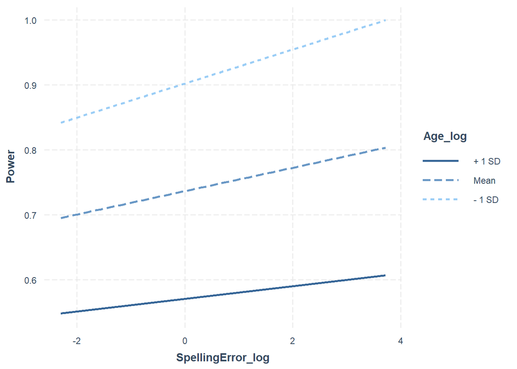

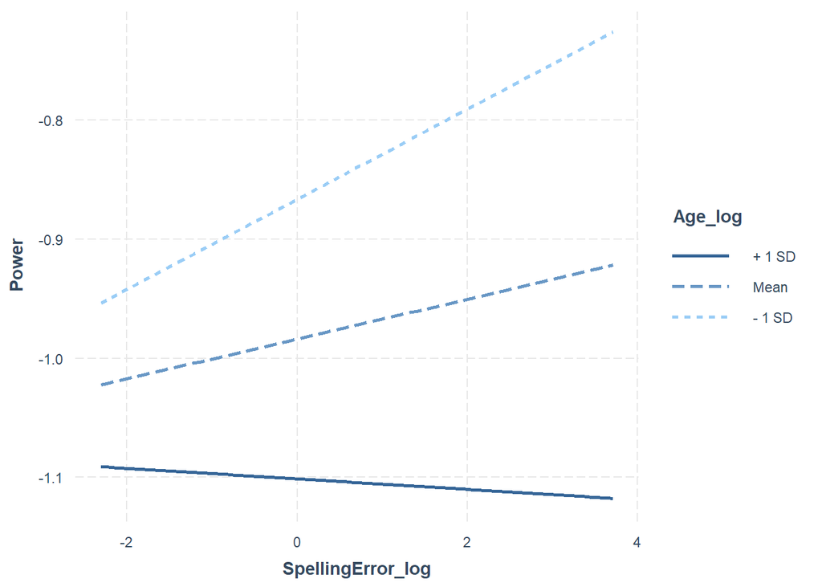

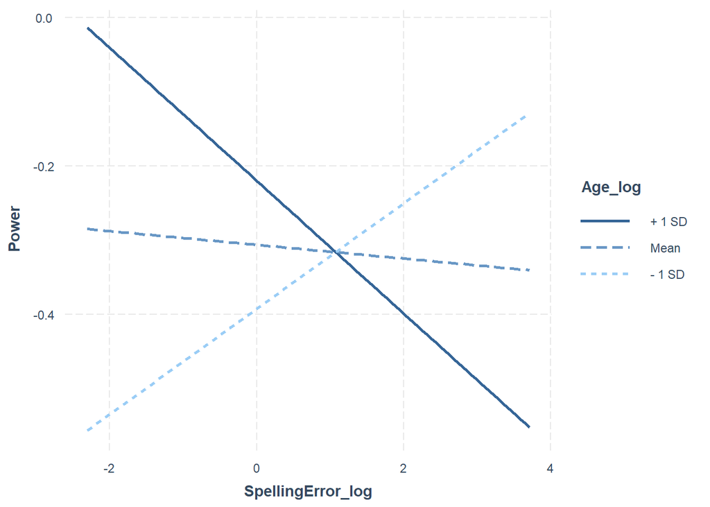

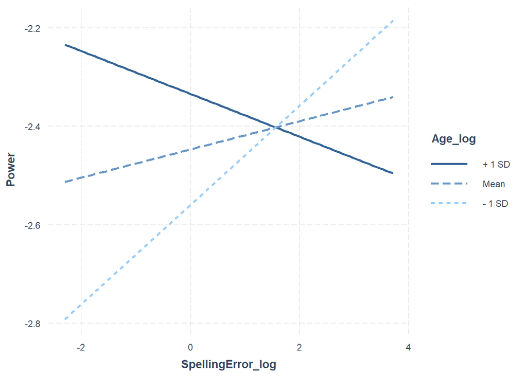

### Model Assumptions

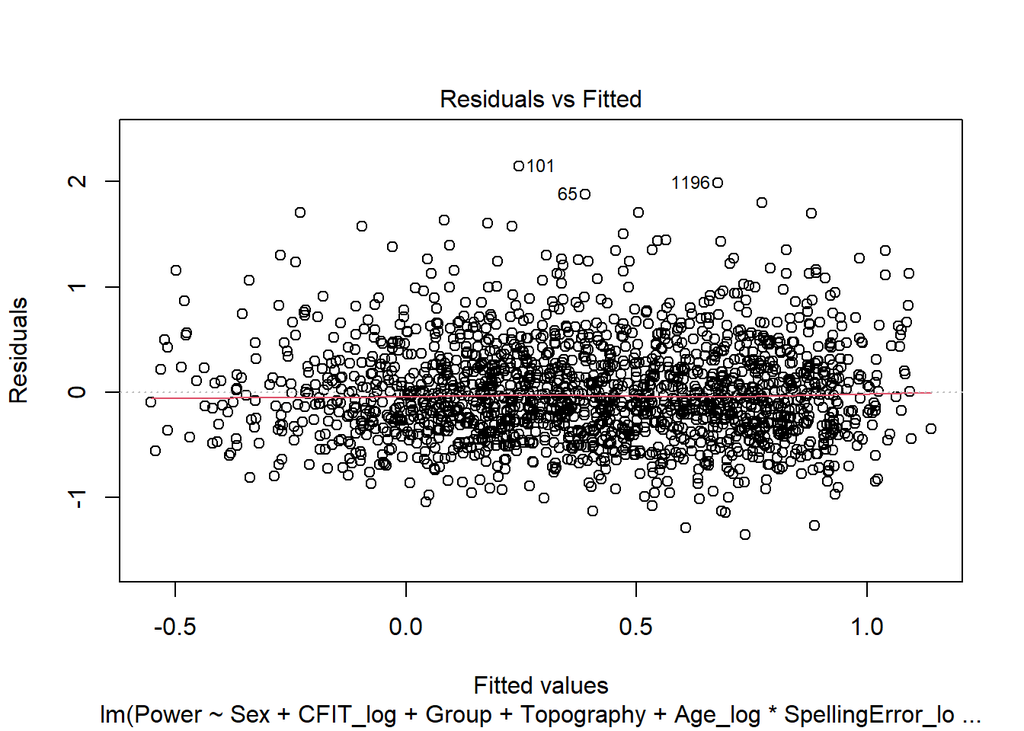

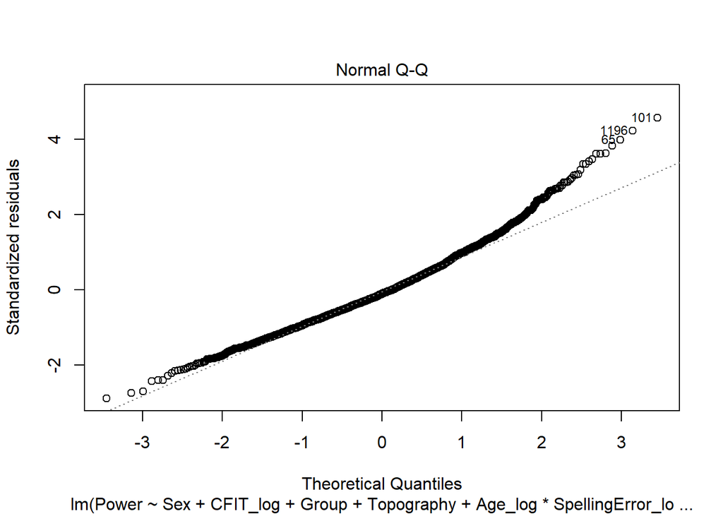

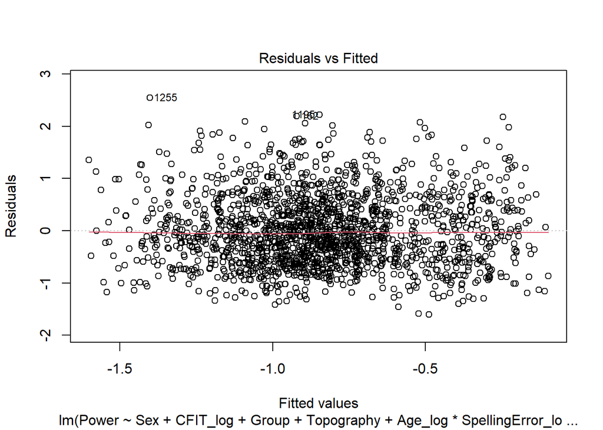

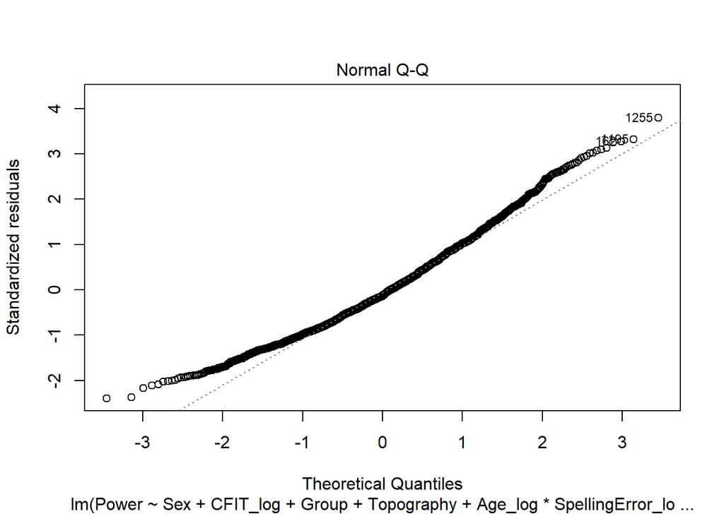